# Analysis of the Adult data set from UCI Machine Learning Repository

This is an analysis of the [Adult data set](http://archive.ics.uci.edu/ml/datasets/Adult) in the UCI Machine Learning Repository.

This data set is meant for binary class classification - to predict whether the income of a person exceeds 50K per year based on some census data.

Our objective here is to familiarize ourselves with scikit-learn by training a Logistic Regression classifier on the data set by using grid search, cross validation and pipeline, and see how well we can do.

At the end of it all, I decided to do a writeup using a Jupyter notebook (which I have pretty much no experience with), so here we are. For those of you reading the HTML version of this notebook, you might have to scroll quite a bit because I have no idea how to toggle the scrolling for the HTML export.

Gist with ipynb file and data set: https://gist.github.com/yanhan/355fb068eb5089b4de78b8de326e6358

## Preliminaries

First, we import the necessary libraries:

```python
from IPython.display import display
from numpy.random import RandomState
from sklearn.linear_model import LogisticRegression, LogisticRegressionCV
from sklearn.metrics import accuracy_score, confusion_matrix, make_scorer, precision_recall_fscore_support, roc_auc_score
from sklearn.model_selection import GridSearchCV, StratifiedKFold, train_test_split
from sklearn.pipeline import Pipeline
from sklearn.preprocessing import RobustScaler, StandardScaler
from sklearn_pandas import DataFrameMapper

import numpy as np
import pandas as pd
```

We create a numpy.random.RandomState so that we can reproduce the same results each time we run this notebook.

```python
rs = RandomState(130917)
```

## Exploratory Data Analysis

This dataset is small and consists of 48842 rows with 14 columns (not counting the column giving the response variable). Hence we can load it entirely into memory. The fields of this data set are delimited by spaces; we can make use of pandas `read_csv` function to load it into memory as a dataframe.

```python
df = pd.read_csv("Dataset.data", header=None, delimiter=r"\s+",)
```

Let's take a look at the first few rows of the dataframe.

```python
print(df.head())
```

```
   0          1       2             3   4                   5   \
0  25    Private  226802          11th   7       Never-married
1  38    Private   89814       HS-grad   9  Married-civ-spouse
2  28  Local-gov  336951    Assoc-acdm  12  Married-civ-spouse
3  44    Private  160323  Some-college  10  Married-civ-spouse
4  18          ?  103497  Some-college  10       Never-married

                  6          7      8       9     10  11  12             13  \
0  Machine-op-inspct  Own-child  Black    Male     0   0  40  United-States
1    Farming-fishing    Husband  White    Male     0   0  50  United-States
2    Protective-serv    Husband  White    Male     0   0  40  United-States
3  Machine-op-inspct    Husband  Black    Male  7688   0  40  United-States
4                  ?  Own-child  White  Female     0   0  30  United-States

      14
0  <=50K
1  <=50K
2   >50K
3   >50K
4  <=50K
```

Seems like everything is as according to the specifications. For ease of human consumption, we assign column names to the dataframe based on the specs.

```python
df.columns = [
    "Age", "WorkClass", "fnlwgt", "Education", "EducationNum",
    "MaritalStatus", "Occupation", "Relationship", "Race", "Gender",
    "CapitalGain", "CapitalLoss", "HoursPerWeek", "NativeCountry", "Income"
]
```

See if there are any NaNs in the dataframe:

```python
df.isnull().values.any()
```

```
False
```

Let's show the first few rows of the dataframe with the column names:

```python
print(df.head())
```

```
   Age  WorkClass  fnlwgt     Education  EducationNum       MaritalStatus  \
0   25    Private  226802          11th             7       Never-married
1   38    Private   89814       HS-grad             9  Married-civ-spouse
2   28  Local-gov  336951    Assoc-acdm            12  Married-civ-spouse
3   44    Private  160323  Some-college            10  Married-civ-spouse
4   18          ?  103497  Some-college            10       Never-married

          Occupation Relationship   Race  Gender  CapitalGain  CapitalLoss  \
0  Machine-op-inspct    Own-child  Black    Male            0            0
1    Farming-fishing      Husband  White    Male            0            0
2    Protective-serv      Husband  White    Male            0            0
3  Machine-op-inspct      Husband  Black    Male         7688            0
4                  ?    Own-child  White  Female            0            0

   HoursPerWeek  NativeCountry Income
0            40  United-States  <=50K
1            50  United-States  <=50K
2            40  United-States   >50K
3            40  United-States   >50K
4            30  United-States  <=50K
```

Let's take a look at the values of the `Income` column:

```python
df.Income.unique()
```

```
array(['<=50K', '>50K'], dtype=object)
```

All good. Let's convert the `<=50K`s into -1 and the `>50K` into +1

```python
df["Income"] = df["Income"].map({ "<=50K": -1, ">50K": 1 })
```

Let's extract the response variable into a numpy array and drop it from the dataframe:

```python
y_all = df["Income"].values
df.drop("Income", axis=1, inplace=True,)
```

Let's look at the data again:

```python
print(df.head())
```

```
   Age  WorkClass  fnlwgt     Education  EducationNum       MaritalStatus  \
0   25    Private  226802          11th             7       Never-married
1   38    Private   89814       HS-grad             9  Married-civ-spouse
2   28  Local-gov  336951    Assoc-acdm            12  Married-civ-spouse
3   44    Private  160323  Some-college            10  Married-civ-spouse
4   18          ?  103497  Some-college            10       Never-married

          Occupation Relationship   Race  Gender  CapitalGain  CapitalLoss  \
0  Machine-op-inspct    Own-child  Black    Male            0            0
1    Farming-fishing      Husband  White    Male            0            0
2    Protective-serv      Husband  White    Male            0            0
3  Machine-op-inspct      Husband  Black    Male         7688            0
4                  ?    Own-child  White  Female            0            0

   HoursPerWeek  NativeCountry
0            40  United-States
1            50  United-States
2            40  United-States
3            40  United-States
4            30  United-States
```

Now, the `Age`, `fnlwgt`, `EducationNum`, `CapitalGain`, `CapitalLoss` and `HoursPerWeek` are clearly numerical. Let's get some summary statistics on these numerical columns:

```python
df.describe()
```

|  | Age | fnlwgt | EducationNum | CapitalGain | CapitalLoss | HoursPerWeek |
| --- | --- | --- | --- | --- | --- | --- |
| count | 48842.000000 | 4.884200e+04 | 48842.000000 | 48842.000000 | 48842.000000 | 48842.000000 |
| mean | 38.643585 | 1.896641e+05 | 10.078089 | 1079.067626 | 87.502314 | 40.422382 |
| std | 13.710510 | 1.056040e+05 | 2.570973 | 7452.019058 | 403.004552 | 12.391444 |
| min | 17.000000 | 1.228500e+04 | 1.000000 | 0.000000 | 0.000000 | 1.000000 |
| 25% | 28.000000 | 1.175505e+05 | 9.000000 | 0.000000 | 0.000000 | 40.000000 |
| 50% | 37.000000 | 1.781445e+05 | 10.000000 | 0.000000 | 0.000000 | 40.000000 |
| 75% | 48.000000 | 2.376420e+05 | 12.000000 | 0.000000 | 0.000000 | 45.000000 |
| max | 90.000000 | 1.490400e+06 | 16.000000 | 99999.000000 | 4356.000000 | 99.000000 |

`Age`, `fnlwgt`, `EducationNum` and `HoursPerWeek` look pretty ok. But `CapitalGain` and `CapitalLoss` both have an IQR of 0. Could they be power law distributions? Let's find out.

```python
df.CapitalGain.value_counts()
```

```
0        44807
15024      513
7688       410
7298       364
99999      244
3103       152
5178       146
5013       117
4386       108
8614        82
3325        81
2174        74
10520       64
4650        63
27828       58
```

[output cut: 47 more lines]

Alright, a whopping 91.7% of the `CapitalGain` consists of 0. Now onto the `CapitalLoss` column:

```python
df.CapitalLoss.value_counts()
```

```
0       46560
1902      304
1977      253
1887      233
2415       72
1485       71
1848       67
1590       62
1602       62
1876       59
1740       58
1672       50
1741       44
1564       43
2258       39
```

[output cut: 47 more lines]

This is even worse. 95.3% of the `CapitalLoss` column consists of 0.

Frankly, I do not know how to handle columns distributed according to power law, so I choose to drop them:

```python
df.drop("CapitalGain", axis=1, inplace=True,)
df.drop("CapitalLoss", axis=1, inplace=True,)
```

Let's convert the `Age`, `fnlwgt`, `EducationNum` and `HoursPerWeek` to floating point so scikit-learn / numpy won't complain about scaling later.

```python
df.Age = df.Age.astype(float)
df.fnlwgt = df.fnlwgt.astype(float)
df.EducationNum = df.EducationNum.astype(float)
df.HoursPerWeek = df.HoursPerWeek.astype(float)
```

Time for the categorical variables. First up `WorkClass`:

```python
df.WorkClass.unique()
```

```
array(['Private', 'Local-gov', '?', 'Self-emp-not-inc', 'Federal-gov',
       'State-gov', 'Self-emp-inc', 'Without-pay', 'Never-worked'], dtype=object)
```

Next up `Education`:

```python
df.Education.unique()
```

```
array(['11th', 'HS-grad', 'Assoc-acdm', 'Some-college', '10th',
       'Prof-school', '7th-8th', 'Bachelors', 'Masters', 'Doctorate',
       '5th-6th', 'Assoc-voc', '9th', '12th', '1st-4th', 'Preschool'], dtype=object)
```

Next up `MaritalStatus`:

```python
df.MaritalStatus.unique()
```

```
array(['Never-married', 'Married-civ-spouse', 'Widowed', 'Divorced',
       'Separated', 'Married-spouse-absent', 'Married-AF-spouse'], dtype=object)
```

Next up `Occupation`:

```python
df.Occupation.unique()
```

```
array(['Machine-op-inspct', 'Farming-fishing', 'Protective-serv', '?',
       'Other-service', 'Prof-specialty', 'Craft-repair', 'Adm-clerical',
       'Exec-managerial', 'Tech-support', 'Sales', 'Priv-house-serv',
       'Transport-moving', 'Handlers-cleaners', 'Armed-Forces'], dtype=object)
```

Next up `Relationship`:

```python
df.Relationship.unique()
```

```
array(['Own-child', 'Husband', 'Not-in-family', 'Unmarried', 'Wife',
       'Other-relative'], dtype=object)
```

Next up `Race`:

```python
df.Race.unique()
```

```
array(['Black', 'White', 'Asian-Pac-Islander', 'Other',
       'Amer-Indian-Eskimo'], dtype=object)
```

Next up `Gender`:

```python
df.Gender.unique()
```

```
array(['Male', 'Female'], dtype=object)
```

Next up `NativeCountry`:

```python
df.NativeCountry.unique()
```

```
array(['United-States', '?', 'Peru', 'Guatemala', 'Mexico',
       'Dominican-Republic', 'Ireland', 'Germany', 'Philippines',
       'Thailand', 'Haiti', 'El-Salvador', 'Puerto-Rico', 'Vietnam',
       'South', 'Columbia', 'Japan', 'India', 'Cambodia', 'Poland', 'Laos',
       'England', 'Cuba', 'Taiwan', 'Italy', 'Canada', 'Portugal', 'China',
       'Nicaragua', 'Honduras', 'Iran', 'Scotland', 'Jamaica', 'Ecuador',
       'Yugoslavia', 'Hungary', 'Hong', 'Greece', 'Trinadad&Tobago',
       'Outlying-US(Guam-USVI-etc)', 'France', 'Holand-Netherlands'], dtype=object)
```

Looks like there's more unique values for `NativeCountry` compared to the other categorical variables. Exactly how many unique values are there?

```python
len(df.NativeCountry.unique())
```

```
42
```

It is not entirely clear what `Relationship` means in this data set, since there is already a `MaritalStatus` column. While it makes sense for someone whose `MaritalStatus` column has the value `Married-civ-spouse` or `Married-AF-spouse` (whatever those 2 values mean) to have `Relationship` column with value `Husband` or `Wife`, can someone's `MaritalStatus` column have the value `Married-civ-spouse` but whose `Relationship` column have value `Own-child` (whatever that means)?

Common sense tells us that `WorkClass`, `Education`, `Occupation` are features with good predictive power with regards to one's income. Similarly for `Race` and `Gender` but to a slightly lesser extent. But how about `MaritalStatus` and the not so clear `Relationship` column?

What about `NativeCountry`? A possible argument for this column is that there may be a higher concentration of people from certain countries in certain occupations. And we know that occupations certainly influence income. But doesn't that make `NativeCountry` redundant? Not entirely. If it is possible for there to be a non-trivial difference between the average income of men and women (with all else equal), then it is possible for there to be a difference between the average income of people from the US and people not from the US who are in the same occupation (again all else being equal). Hence this feature could have predictive power as well.

Long story short, we choose to retain all these columns and use one-hot encoding to transform them into numerical features that the Logistic Regression model we're using later can consume.

```python
df = pd.get_dummies(df, columns=[
    "WorkClass", "Education", "MaritalStatus", "Occupation", "Relationship",
    "Race", "Gender", "NativeCountry",
])
```

What are the dimensions of our dataframe?

```python
df.shape
```

```
(48842, 106)
```

## Splitting the data for training and testing

Is our data imbalanced towards one class?

```python
pd.value_counts(pd.Series(y_all))
```

```
-1    37155
 1    11687
dtype: int64
```

Turns out, yes. Only 23.9% of the data belongs to the positive class. This is something we'll have to keep in mind when training the classifier later.

We'll do a stratified split of the data set into a training set and a test set, with 25% of the data going into the test set. A stratified split will ensure that the percentage of every class in the training set and test set is very similar to that of the entire data set.

Recall the `RandomState` variable in `rs` that we created right at the start of the file? We pass that in to the `random_state` argument of the `train_test_split` function:

```python
X_train, X_test, y_train, y_test = train_test_split(
    df, y_all, test_size=0.25, stratify=y_all, random_state=rs,
)
```

## The Machine Learning part

Recall that we have 4 numerical columns: `Age`, `fnlwgt`, `EducationNum` and `HoursPerWeek`. We will have to scale the data. For simplicity, we choose to use `StandardScaler`. No scaling / transformation will be done for the rest of the columns. We use the DataFrameMapper from the sklearn-pandas package to accomplish this.

```python
standard_scaler_cols = ["Age", "fnlwgt", "EducationNum", "HoursPerWeek",]
other_cols = list(set(df.columns) - set(standard_scaler_cols))
mapper = DataFrameMapper(
    [([col,], StandardScaler(),) for col in standard_scaler_cols] +
    [(col, None,) for col in other_cols]
)
```

Now we create our pipeline, which will consist of 2 steps:

1. Scaling the 4 numerical columns using DataFrameMapper
2. Training a Logistic Regression classifier

The `RandomState` variable `rs` is passed into the Logistic Regression classifier.

```python
clf = LogisticRegression(random_state=rs,)
pipeline = Pipeline([
    ("scale", mapper,),
    ("logit", clf,)
])
```

We are going to perform a grid search with cross validation over 2 "hyperparameters":

1. The `C` argument to `LogisticRegression` indicating the inverse of the regularization strength. We're going to vary this from 1e-04 to 1e4 with a 10x increase from one value to the next. This is a legit hyperparameter.
2. The `class_weight` argument to `LogisticRegression`. Seems like setting this to `balanced` could help out in our case where the classes are imbalanced. Not sure whether this is a real hyperparameter to Logistic Regression which is why I put the hyperparameters in quotes.

For scoring, we will make use of `roc_auc_score` instead of the default accuracy, because of the imbalance in classes. ROC AUC score also has an intuitive appeal in that it represents the probability of the classifier ranking a randomly selected positive instance over a randomly selected negative instance

To make the results repeatable, we create a `StratifiedKFold` object and pass it the `RandomState` variable `rs`. Then we pass the `StratifiedKFold` object as the cross validation generator via the `cv` argument of the `GridSearchCV` object.

```python
strat_kfold = StratifiedKFold(10, random_state=rs,)
estimator = GridSearchCV(
    pipeline,
    param_grid={
        "logit__C": np.power(10, np.arange(-4.0, 5.0)),
        "logit__class_weight": ["balanced", None,],
    },
    scoring=make_scorer(roc_auc_score),
    cv=strat_kfold,
)
```

Now we perform the grid search with cross validation and print out the results.

I chose to disable this warning because there's so many of them:

```
DeprecationWarning: Estimator DataFrameMapper modifies parameters in __init__. This behavior is deprecated as of 0.18 and support for this behavior will be removed in 0.20.
```

It should have been resolved in one of the issues for the `sklearn-pandas` package but for some reason it has resurfaced.

Credits to this [Stack Overflow answer](http://stackoverflow.com/a/9031848)

```python
import warnings
warnings.filterwarnings("ignore")
estimator.fit(X_train, y_train)
```

```
GridSearchCV(cv=StratifiedKFold(n_splits=10,
        random_state=<mtrand.RandomState object at 0x7fda6e21e438>,
        shuffle=False),
       error_score='raise',
       estimator=Pipeline(steps=[('scale', DataFrameMapper(default=False, df_out=False,
        features=[(['Age'], StandardScaler(copy=True, with_mean=True, with_std=True)), (['fnlwgt'], StandardScaler(copy=True, with_mean=True, with_std=True)), (['EducationNum'], StandardScaler(copy=True, with_mean=True, with_std=True)), (... object at 0x7fda6e21e438>,
          solver='liblinear', tol=0.0001, verbose=0, warm_start=False))]),
       fit_params={}, iid=True, n_jobs=1,
       param_grid={'logit__C': array([  1.00000e-04,   1.00000e-03,   1.00000e-02,   1.00000e-01,
         1.00000e+00,   1.00000e+01,   1.00000e+02,   1.00000e+03,
         1.00000e+04]), 'logit__class_weight': ['balanced', None]},
       pre_dispatch='2*n_jobs', refit=True, return_train_score=True,
       scoring=make_scorer(roc_auc_score), verbose=0)
```

Let's look at the results in a pandas DataFrame:

```python
cv_results_df = pd.DataFrame(estimator.cv_results_)
cv_results_df.sort_values(by="rank_test_score").head(5)
```

|  | mean_fit_time | mean_score_time | mean_test_score | mean_train_score | param_logit__C | param_logit__class_weight | params | rank_test_score | split0_test_score | split0_train_score | ... | split7_test_score | split7_train_score | split8_test_score | split8_train_score | split9_test_score | split9_train_score | std_fit_time | std_score_time | std_test_score | std_train_score |
| --- | --- | --- | --- | --- | --- | --- | --- | --- | --- | --- | --- | --- | --- | --- | --- | --- | --- | --- | --- | --- | --- |
| 4 | 0.166931 | 0.010015 | 0.806727 | 0.807109 | 0.01 | balanced | {'logit__C': 0.01, 'logit__class_weight': 'bal... | 1 | 0.820290 | 0.805417 | ... | 0.807479 | 0.806635 | 0.802130 | 0.808239 | 0.808735 | 0.807573 | 0.002707 | 0.000833 | 0.009891 | 0.001270 |
| 6 | 0.194077 | 0.009795 | 0.806065 | 0.807942 | 0.1 | balanced | {'logit__C': 0.1, 'logit__class_weight': 'bala... | 2 | 0.821777 | 0.806334 | ... | 0.805752 | 0.808329 | 0.804611 | 0.808550 | 0.804007 | 0.808412 | 0.001292 | 0.000393 | 0.010309 | 0.000976 |
| 8 | 0.258479 | 0.013917 | 0.805728 | 0.807752 | 1 | balanced | {'logit__C': 1.0, 'logit__class_weight': 'bala... | 3 | 0.819529 | 0.805887 | ... | 0.805752 | 0.808108 | 0.803469 | 0.808626 | 0.803975 | 0.808495 | 0.025620 | 0.011498 | 0.010077 | 0.000990 |
| 10 | 0.349818 | 0.010560 | 0.804717 | 0.807950 | 10 | balanced | {'logit__C': 10.0, 'logit__class_weight': 'bal... | 4 | 0.818389 | 0.806247 | ... | 0.805573 | 0.808421 | 0.801969 | 0.808776 | 0.804154 | 0.808249 | 0.043081 | 0.001983 | 0.009919 | 0.000946 |
| 14 | 0.413492 | 0.013878 | 0.804699 | 0.807990 | 1000 | balanced | {'logit__C': 1000.0, 'logit__class_weight': 'b... | 5 | 0.818389 | 0.806267 | ... | 0.805752 | 0.808465 | 0.801969 | 0.808859 | 0.804154 | 0.808416 | 0.084363 | 0.011494 | 0.009904 | 0.000984 |

5 rows × 32 columns

Best parameters for Logistic Regression:

```python
print(estimator.best_params_)
```

```
{'logit__C': 0.01, 'logit__class_weight': 'balanced'}
```

Ok, so setting `class_weight` to `balanced` does help for Logistic Regression. The best regularization `C` is `0.01`.

Now we write a function to build a pandas DataFrame from a confusion matrix:

```python
def _build_df_from_confusion_matrix(confusion_matrix, as_fractions=False):
    if as_fractions:
        x = np.array(confusion_matrix)
        x = np.apply_along_axis(
            lambda row: [
                row[0] / (row[0] + row[1]),
                row[1] / (row[0] + row[1])
            ],
            1,
            x
        )
    else:
        x = confusion_matrix
    df = pd.DataFrame(
        x,
        index=["<= 50K", "> 50K"],
        columns=["<= 50K", "> 50K"]
    )
    df.index.names = ["Actual"]
    df.columns.names = ["Predicted"]
    return df
```

### Performance on training set

```python
y_train_predicted = estimator.predict(X_train)
print("Training set accuracy score: {}".format(
    accuracy_score(y_train, y_train_predicted)
))
print("Training set AUROC score: {}".format(estimator.score(X_train, y_train)))
print("\nConfusion matrix for training set:")
training_confusion_matrix = confusion_matrix(
    y_train, y_train_predicted
)
display(_build_df_from_confusion_matrix(training_confusion_matrix))
print("Same as above but in fractions:")
display(_build_df_from_confusion_matrix(training_confusion_matrix, as_fractions=True))
print("Precision, recall, f-score:")
precision_recall_fscore_support(y_train, y_train_predicted)
```

```
Training set accuracy score: 0.785755234637329
Training set AUROC score: 0.8071775040759195

Confusion matrix for training set:
```

| Predicted Actual | <= 50K | > 50K |
| --- | --- | --- |
| <= 50K | 21348 | 6518 |
| > 50K | 1330 | 7435 |

```
Same as above but in fractions:
```

| Predicted Actual | <= 50K | > 50K |
| --- | --- | --- |
| <= 50K | 0.766095 | 0.233905 |
| > 50K | 0.151740 | 0.848260 |

```
Precision, recall, f-score:
```

```
(array([ 0.94135285,  0.53286032]),
 array([ 0.76609488,  0.84826013]),
 array([ 0.84472934,  0.65454706]),
 array([27866,  8765]))
```

While the AUROC score of 0.8071775040759195 seems decent, the precision, recall and fscore tells a different story.

That said, the recall for the positive class is 84.826%. So this classifier captures a good part of the instances that belong to the positive class.

I have no idea how to interpret the f-score and I have no time to learn how to do it so I will skip that.

But this is for the training set. How about the test set?

### Performance on test set

```python
y_test_predicted = estimator.predict(X_test)
print("Test set accuracy score: {}".format(
    accuracy_score(y_test, y_test_predicted)
))
print("Test set AUROC score: {}".format(estimator.score(X_test, y_test)))
print("\nConfusion matrix for test set:")
test_confusion_matrix = confusion_matrix(y_test, y_test_predicted)
display(_build_df_from_confusion_matrix(test_confusion_matrix))
print("Same as above but in fractions:")
display(_build_df_from_confusion_matrix(test_confusion_matrix, as_fractions=True))
print("Precision, recall, f-score:")
precision_recall_fscore_support(y_test, y_test_predicted)
```

```
Test set accuracy score: 0.7903529604455
Test set AUROC score: 0.8116512329133934

Confusion matrix for test set:
```

| Predicted Actual | <= 50K | > 50K |
| --- | --- | --- |
| <= 50K | 7160 | 2129 |
| > 50K | 431 | 2491 |

```
Same as above but in fractions:
```

| Predicted Actual | <= 50K | > 50K |
| --- | --- | --- |
| <= 50K | 0.770804 | 0.229196 |
| > 50K | 0.147502 | 0.852498 |

```
Precision, recall, f-score:
```

```
(array([ 0.94322224,  0.53917749]),
 array([ 0.77080418,  0.85249829]),
 array([ 0.84834123,  0.66056749]),
 array([9289, 2922]))
```

We get very similar numbers for the test set. Seems like the classifier performed slightly better for the test set than the training set. Which is kind of strange. But I guess this means that the Logistic Regression algorithm has learnt something from the data.

So we have a classifier with good recall but bad precision. This is great if we want to identify as many people with income exceeding 50K per annum as possible, but it is not so great when we realize that almost half the people identified as income exceeding 50K per annum actually earn less than 50K per annum.

This not so great performance could be mainly attributed to us dropping the `CapitalGain` and `CapitalLoss` columns. I'm not entirely sure how to deal with those but an idea is to take logarithm of those columns - we can handle zeros by adding 1 to the entire column.

Another idea is to add polynomial features. This can be done without too much effort in scikit-learn. The major downside is that we already had 106 features after dropping the `CapitalGain` and `CapitalLoss` columns. With those 2 columsn we will have 108 features. With polynomial features, this number can easily triple. Grid search will take a lot more time to complete.

## Conclusion

A pretty good deal I'd say. The next time, I will perform some analysis / learning on a 'more real' dataset.

## Addendum - Making use of the `CapitalGain` and `CapitalLoss` features

One fine day I recalled seeing that there are no negative values in the `CapitalGain` and `CapitalLoss` columns - the minimum value is zero. Perhaps we can do take logarithms and see how the resulting values are distributed.

```
Min: 0.0, Max: 11.512925464970229
```

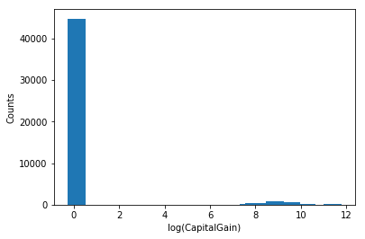

```python
# Same code from above to re create the dataframe
df = pd.read_csv("Dataset.data", header=None, delimiter=r"\s+",)
df.columns = [
    "Age", "WorkClass", "fnlwgt", "Education", "EducationNum",
    "MaritalStatus", "Occupation", "Relationship", "Race", "Gender",
    "CapitalGain", "CapitalLoss", "HoursPerWeek", "NativeCountry", "Income"
]
%matplotlib inline
import matplotlib.pyplot as plt

log_capital_gain = np.log(df.CapitalGain + 1)
print("Min: {}, Max: {}".format(
    np.min(log_capital_gain), np.max(log_capital_gain)
))
hist, bins = np.histogram(log_capital_gain, bins=50)
plt.bar((bins[:-1] + bins[1:]) / 2, hist, align="center",)
plt.xlabel("log(CapitalGain)")
plt.ylabel("Counts")
```

```
Min: 0.0, Max: 8.379539026117442
```

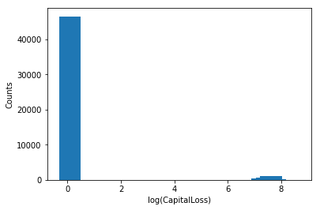

```python
log_capital_loss = np.log(df.CapitalLoss + 1)
print("Min: {}, Max: {}".format(
    np.min(log_capital_loss), np.max(log_capital_loss)
))
hist, bins = np.histogram(log_capital_loss, bins=50)
plt.bar((bins[:-1] + bins[1:]) / 2, hist, align="center",)
plt.xlabel("log(CapitalLoss)")
plt.ylabel("Counts")
```

Hmm so I remembered the wrong stuff. After scaling, the values in these 2 columns will still be distributed very similarly as before the scaling is done. A log-log plot of both the counts and the values should show approximately a linear trend. Let's do that.

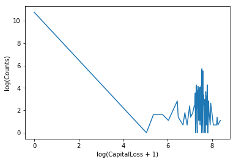

```python
len_of_range = np.max(df.CapitalLoss) + 1
m = np.hstack(
    (
        np.array(range(len_of_range)).reshape((len_of_range, 1,)),
        np.bincount(df.CapitalLoss).reshape((len_of_range, 1,)),
    )
)
m = m[m[:, 1] > 0]
m[:, 0] += 1
m = np.log(m)
plt.plot(m[:, 0], m[:, 1])
plt.xlabel("log(CapitalLoss + 1)")
plt.ylabel("log(Counts)")
```

Oops, wrong type of plot. Let's try fitting a line and plot the points in a scatter plot.

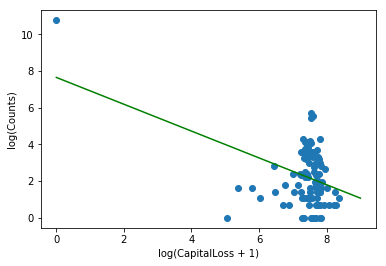

```python
coeffs = np.polyfit(m[:, 0], m[:, 1], 1)
plt.scatter(m[:, 0], m[:, 1], marker="o")
x = np.arange(0, 10)
plt.plot(x, coeffs[0] * x + coeffs[1], color="green")
plt.xlabel("log(CapitalLoss + 1)")
plt.ylabel("log(Counts)")
```

Ok, this is pretty much the same too and totally not what we envisioned things to be. Ack.

I recalled seeing at a talk someone plotting a distribution of a single variable grouped by classes, with each curve for a class colored differently. A little googling yields these results: http://stackoverflow.com/a/31258153/732396 http://stackoverflow.com/a/32748510/732396

which we make use of in the plots below:

```
Income
<=50K    Axes(0.125,0.125;0.775x0.755)
>50K     Axes(0.125,0.125;0.775x0.755)
Name: CapitalLoss, dtype: object
```

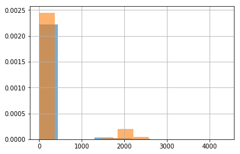

```python
df.groupby("Income").CapitalLoss.hist(normed=1, alpha=0.6,)
```

```
Income
<=50K    Axes(0.125,0.125;0.775x0.755)
>50K     Axes(0.125,0.125;0.775x0.755)
Name: CapitalGain, dtype: object
```

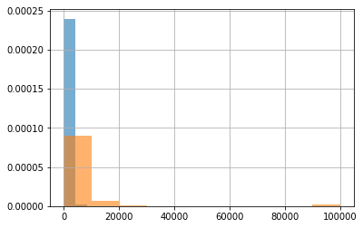

```python
df.groupby("Income").CapitalGain.hist(normed=1, alpha=0.6)
```

I also recall hearing that if there is a marked difference between the distribution of the points between the two classes, then that variable should be a good feature. In this case, what we see from these plots is not exactly great, because for both classes, the majority of the values are concentrated near 0.

Just realized the income isn't at a log scale. Let's take logs.

```
Income
<=50K    Axes(0.125,0.125;0.775x0.755)
>50K     Axes(0.125,0.125;0.775x0.755)
Name: CapitalLoss, dtype: object
```

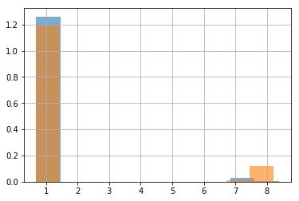

```python
df2 = df.copy()
df2.CapitalLoss = df2.CapitalLoss + 1
df2.CapitalLoss = df2.CapitalLoss.apply(lambda r: np.log(r + 1))
df2.groupby("Income").CapitalLoss.hist(normed=1, alpha=0.6,)
```

```
Income
<=50K    Axes(0.125,0.125;0.775x0.755)
>50K     Axes(0.125,0.125;0.775x0.755)
Name: CapitalGain, dtype: object
```

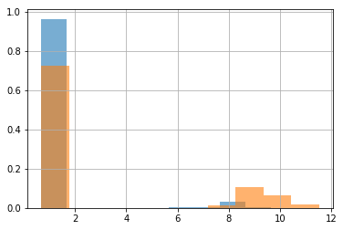

```python
df2.CapitalGain = df2.CapitalGain + 1
df2.CapitalGain = df2.CapitalGain.apply(lambda r: np.log(r + 1))
df2.groupby("Income").CapitalGain.hist(normed=1, alpha=0.6,)
```

The situation is similar. Never mind.

Onto the machine learning. For the `CapitalLoss` and `CapitalGain` columns, we will add 1 to all the values and then take logs. This will not leak data from the test set into the training set. Ultimately, we will be using `StandardScaler` to transform those 2 columns before passing the data to Logistic Regression.

```python
df.CapitalGain = df.CapitalGain + 1
df.CapitalGain = df.CapitalGain.apply(lambda r: np.log(r + 1))
df.CapitalLoss = df.CapitalLoss + 1
df.CapitalLoss = df.CapitalLoss.apply(lambda r: np.log(r + 1))

# Apply what's necessary amongst the stuff we did earlier
df["Income"] = df["Income"].map({ "<=50K": -1, ">50K": 1 })
y_all = df.Income.values
df = pd.get_dummies(df, columns=[
    "WorkClass", "Education", "MaritalStatus", "Occupation", "Relationship",
    "Race", "Gender", "NativeCountry",
])
# We have to redo the train-test split because of the new columns
df.drop("Income", axis=1, inplace=True,)
X_train, X_test, y_train, y_test = train_test_split(
    df, y_all, test_size=0.25, stratify=y_all, random_state=rs,
)

# Note the newly added `CapitalGain` and `CapitalLoss` columns
standard_scaler_cols = [
    "Age", "fnlwgt", "EducationNum", "CapitalGain", "CapitalLoss", "HoursPerWeek",
]
other_cols = list(set(df.columns) - set(standard_scaler_cols))

# We need to create a new `DataFrameMapper` and `Pipeline` object to
# incorporate those 2 columns
mapper = DataFrameMapper(
    [([col,], StandardScaler(),) for col in standard_scaler_cols] +
    [(col, None,) for col in other_cols]
)
clf = LogisticRegression(random_state=rs,)
pipeline = Pipeline([
    ("scale", mapper,),
    ("logit", clf,)
])
strat_kfold = StratifiedKFold(10, random_state=rs,)
estimator = GridSearchCV(
    pipeline,
    param_grid={
        "logit__C": np.power(10, np.arange(-4.0, 5.0)),
        "logit__class_weight": ["balanced", None,],
    },
    scoring=make_scorer(roc_auc_score),
    cv=strat_kfold,
)
estimator.fit(X_train, y_train)
```

```
GridSearchCV(cv=StratifiedKFold(n_splits=10,
        random_state=<mtrand.RandomState object at 0x7fda6e21e438>,
        shuffle=False),
       error_score='raise',
       estimator=Pipeline(steps=[('scale', DataFrameMapper(default=False, df_out=False,
        features=[(['Age'], StandardScaler(copy=True, with_mean=True, with_std=True)), (['fnlwgt'], StandardScaler(copy=True, with_mean=True, with_std=True)), (['EducationNum'], StandardScaler(copy=True, with_mean=True, with_std=True)), (... object at 0x7fda6e21e438>,
          solver='liblinear', tol=0.0001, verbose=0, warm_start=False))]),
       fit_params={}, iid=True, n_jobs=1,
       param_grid={'logit__C': array([  1.00000e-04,   1.00000e-03,   1.00000e-02,   1.00000e-01,
         1.00000e+00,   1.00000e+01,   1.00000e+02,   1.00000e+03,
         1.00000e+04]), 'logit__class_weight': ['balanced', None]},
       pre_dispatch='2*n_jobs', refit=True, return_train_score=True,
       scoring=make_scorer(roc_auc_score), verbose=0)
```

```python
cv_results_df = pd.DataFrame(estimator.cv_results_)
cv_results_df.sort_values(by="rank_test_score").head(5)
```

|  | mean_fit_time | mean_score_time | mean_test_score | mean_train_score | param_logit__C | param_logit__class_weight | params | rank_test_score | split0_test_score | split0_train_score | ... | split7_test_score | split7_train_score | split8_test_score | split8_train_score | split9_test_score | split9_train_score | std_fit_time | std_score_time | std_test_score | std_train_score |
| --- | --- | --- | --- | --- | --- | --- | --- | --- | --- | --- | --- | --- | --- | --- | --- | --- | --- | --- | --- | --- | --- |
| 8 | 0.279067 | 0.010767 | 0.817050 | 0.818658 | 1 | balanced | {'logit__C': 1.0, 'logit__class_weight': 'bala... | 1 | 0.815697 | 0.819107 | ... | 0.827235 | 0.816955 | 0.824332 | 0.817792 | 0.812133 | 0.818966 | 0.005344 | 0.000906 | 0.006772 | 0.001005 |
| 6 | 0.202885 | 0.010831 | 0.816884 | 0.818323 | 0.1 | balanced | {'logit__C': 0.1, 'logit__class_weight': 'bala... | 2 | 0.815307 | 0.819285 | ... | 0.825979 | 0.817276 | 0.824364 | 0.817009 | 0.810812 | 0.818844 | 0.003923 | 0.000269 | 0.006716 | 0.001009 |
| 10 | 0.394470 | 0.010514 | 0.816636 | 0.818783 | 10 | balanced | {'logit__C': 10.0, 'logit__class_weight': 'bal... | 3 | 0.814980 | 0.819033 | ... | 0.826844 | 0.817105 | 0.824723 | 0.817899 | 0.810992 | 0.819069 | 0.031814 | 0.001020 | 0.006850 | 0.001017 |
| 14 | 0.600169 | 0.010419 | 0.816540 | 0.818817 | 1000 | balanced | {'logit__C': 1000.0, 'logit__class_weight': 'b... | 4 | 0.814980 | 0.818973 | ... | 0.826844 | 0.817315 | 0.824723 | 0.817962 | 0.811351 | 0.819089 | 0.067916 | 0.000588 | 0.006799 | 0.000943 |
| 12 | 0.555784 | 0.010368 | 0.816540 | 0.818803 | 100 | balanced | {'logit__C': 100.0, 'logit__class_weight': 'ba... | 4 | 0.814980 | 0.818973 | ... | 0.826844 | 0.817315 | 0.824723 | 0.817855 | 0.811351 | 0.819089 | 0.038998 | 0.000374 | 0.006799 | 0.000959 |

5 rows × 32 columns

```python
print(estimator.best_params_)
```

```
{'logit__C': 1.0, 'logit__class_weight': 'balanced'}
```

As opposed to the case without the `CapitalGain` and `CapitalLoss` columns, the regularization parameter is 1.0 here, as opposed to 0.01 .

```python
y_train_predicted = estimator.predict(X_train)
print("Training set accuracy score: {}".format(
    accuracy_score(y_train, y_train_predicted)
))
print("Training set AUROC score: {}".format(estimator.score(X_train, y_train)))
print("\nConfusion matrix for training set:")
training_confusion_matrix = confusion_matrix(
    y_train, y_train_predicted
)
display(_build_df_from_confusion_matrix(training_confusion_matrix))
print("Same as above but in fractions:")
display(_build_df_from_confusion_matrix(training_confusion_matrix, as_fractions=True))
print("Precision, recall, f-score:")
precision_recall_fscore_support(y_train, y_train_predicted)
```

```
Training set accuracy score: 0.8053561191340668
Training set AUROC score: 0.8188093217197174

Confusion matrix for training set:
```

| Predicted Actual | <= 50K | > 50K |
| --- | --- | --- |
| <= 50K | 22098 | 5768 |
| > 50K | 1362 | 7403 |

```
Same as above but in fractions:
```

| Predicted Actual | <= 50K | > 50K |
| --- | --- | --- |
| <= 50K | 0.793009 | 0.206991 |
| > 50K | 0.155391 | 0.844609 |

```
Precision, recall, f-score:
```

```
(array([ 0.94194373,  0.56206818]),
 array([ 0.7930094 ,  0.84460924]),
 array([ 0.86108405,  0.67496353]),
 array([27866,  8765]))
```

Results from without the `CapitalGain` and `CapitalLoss` columns:

```
Training set accuracy score: 0.785755234637329
Training set AUROC score: 0.8071775040759195

Precision, recall, f-score:

(array([ 0.94135285,  0.53286032]),
 array([ 0.76609488,  0.84826013]),
 array([ 0.84472934,  0.65454706]),
 array([27866,  8765]))
```

```python
y_test_predicted = estimator.predict(X_test)
print("Test set accuracy score: {}".format(
    accuracy_score(y_test, y_test_predicted)
))
print("Test set AUROC score: {}".format(estimator.score(X_test, y_test)))
print("\nConfusion matrix for test set:")
test_confusion_matrix = confusion_matrix(y_test, y_test_predicted)
display(_build_df_from_confusion_matrix(test_confusion_matrix))
print("Same as above but in fractions:")
display(_build_df_from_confusion_matrix(test_confusion_matrix, as_fractions=True))
print("Precision, recall, f-score:")
precision_recall_fscore_support(y_test, y_test_predicted)
```

```
Test set accuracy score: 0.8048480877896979
Test set AUROC score: 0.818598282440006

Confusion matrix for test set:
```

| Predicted Actual | <= 50K | > 50K |
| --- | --- | --- |
| <= 50K | 7359 | 1930 |
| > 50K | 453 | 2469 |

```
Same as above but in fractions:
```

| Predicted Actual | <= 50K | > 50K |
| --- | --- | --- |
| <= 50K | 0.792227 | 0.207773 |
| > 50K | 0.155031 | 0.844969 |

```
Precision, recall, f-score:
```

```
(array([ 0.94201229,  0.56126392]),
 array([ 0.79222737,  0.8449692 ]),
 array([ 0.86065142,  0.67449802]),
 array([9289, 2922]))
```

Results from without the `CapitalGain` and `CapitalLoss` columns:

```
Test set accuracy score: 0.7903529604455
Test set AUROC score: 0.8116512329133934

Precision, recall, f-score:

(array([ 0.94322224,  0.53917749]),
 array([ 0.77080418,  0.85249829]),
 array([ 0.84834123,  0.66056749]),
 array([9289, 2922]))
```

Incorporating the `CapitalGain` and `CapitalLoss` columns have improved the accuracy and AUROC scores slightly. Similarly for precision for the positive class. Recall for the positive class dropped slightly but recall for the negative class increased.

Comparing the confusion matrices, we see that by incorporating these 2 columns, there is a decrease in the number of false positives but an increase in the number of false negatives.

Is this a better classifier? Arguably.

## Cheating

I definitely need more experience playing around with data sets and machine learning algorithms. Since I already have some stuff here, why not go further? What I want to do:

1. Polynomial Features
2. Feature Selection using PCA
3. Train Logistic Regression on the PCA learned features

**NOTE:** The stuff in this section can take really long to run on a normal PC and can take up to 16GB of RAM on same occasions. Eventually I decided to spin up a c4.8xlarge EC2 instance on AWS to run this. It costs over $2 USD an hour just to run the instance and the cross validation took over an hour.

```python
from sklearn.preprocessing import PolynomialFeatures

poly = PolynomialFeatures(degree=2, include_bias=False,)
df_cheat = poly.fit_transform(df)
print(df_cheat.shape)
```

```
(48842, 5994)
```

I wanted to do degree 3 polynomial features but that the memory require exceeded that on my system because dense matrices are required. Using degree 2 polynomial feature transformation, we got a total of 108 (original features) + 108 (original features to 2nd power) + (108 choose 2 = 5778 interaction features) = 5994 features. Wow.\

Let's restore the column names. Code modified from http://stackoverflow.com/a/36735970

```python
df_cheat = pd.DataFrame(data=df_cheat)
df_cheat.columns = [
    " * ".join([
        ("{}^{}".format(col, power) if power > 1 else col)
        for col, power in cols_zipped_with_powers if power > 0
    ])
    for cols_zipped_with_powers in [zip(df.columns, p) for p in poly.powers_]
]
df_cheat.head()
```

|  | Age | fnlwgt | EducationNum | CapitalGain | CapitalLoss | HoursPerWeek | WorkClass_? | WorkClass_Federal-gov | WorkClass_Local-gov | WorkClass_Never-worked | ... | NativeCountry_Trinadad&Tobago^2 | NativeCountry_Trinadad&Tobago * NativeCountry_United-States | NativeCountry_Trinadad&Tobago * NativeCountry_Vietnam | NativeCountry_Trinadad&Tobago * NativeCountry_Yugoslavia | NativeCountry_United-States^2 | NativeCountry_United-States * NativeCountry_Vietnam | NativeCountry_United-States * NativeCountry_Yugoslavia | NativeCountry_Vietnam^2 | NativeCountry_Vietnam * NativeCountry_Yugoslavia | NativeCountry_Yugoslavia^2 |
| --- | --- | --- | --- | --- | --- | --- | --- | --- | --- | --- | --- | --- | --- | --- | --- | --- | --- | --- | --- | --- | --- |
| 0 | 25.0 | 226802.0 | 7.0 | 0.693147 | 0.693147 | 40.0 | 0.0 | 0.0 | 0.0 | 0.0 | ... | 0.0 | 0.0 | 0.0 | 0.0 | 1.0 | 0.0 | 0.0 | 0.0 | 0.0 | 0.0 |
| 1 | 38.0 | 89814.0 | 9.0 | 0.693147 | 0.693147 | 50.0 | 0.0 | 0.0 | 0.0 | 0.0 | ... | 0.0 | 0.0 | 0.0 | 0.0 | 1.0 | 0.0 | 0.0 | 0.0 | 0.0 | 0.0 |
| 2 | 28.0 | 336951.0 | 12.0 | 0.693147 | 0.693147 | 40.0 | 0.0 | 0.0 | 1.0 | 0.0 | ... | 0.0 | 0.0 | 0.0 | 0.0 | 1.0 | 0.0 | 0.0 | 0.0 | 0.0 | 0.0 |
| 3 | 44.0 | 160323.0 | 10.0 | 8.947676 | 0.693147 | 40.0 | 0.0 | 0.0 | 0.0 | 0.0 | ... | 0.0 | 0.0 | 0.0 | 0.0 | 1.0 | 0.0 | 0.0 | 0.0 | 0.0 | 0.0 |
| 4 | 18.0 | 103497.0 | 10.0 | 0.693147 | 0.693147 | 30.0 | 1.0 | 0.0 | 0.0 | 0.0 | ... | 0.0 | 0.0 | 0.0 | 0.0 | 1.0 | 0.0 | 0.0 | 0.0 | 0.0 | 0.0 |

5 rows × 5994 columns

Looks correct to me.

We'll do the train-test split before dimensionality reduction using PCA. We'll also do scaling for the columns containing learned features so PCA is not affected by the range of values for the polynomial features.

```python
X_train, X_test, y_train, y_test = train_test_split(
    df_cheat, y_all, test_size=0.25, stratify=y_all, random_state=rs,
)
standard_scaler_cols = [
    "Age", "fnlwgt", "EducationNum", "CapitalGain", "CapitalLoss", "HoursPerWeek",
] + list(df_cheat.columns[108:])
other_cols = list(set(df_cheat.columns) - set(standard_scaler_cols))

mapper = DataFrameMapper(
    [([col,], StandardScaler(),) for col in standard_scaler_cols] +
    [(col, None,) for col in other_cols]
)
```

```python
from sklearn.decomposition import PCA
pca = PCA()
pca.fit(mapper.fit_transform(X_train))
```

```
PCA(copy=True, iterated_power='auto', n_components=None, random_state=None,
  svd_solver='auto', tol=0.0, whiten=False)
```

```python
np.cumsum(pca.explained_variance_ratio_)
```

```
array([ 0.01134274,  0.01871352,  0.02537224, ...,  1.        ,
        1.        ,  1.        ])
```

Let's find the number of components such that the explained variance exceeds 0.9

```python
np.argmax(np.cumsum(pca.explained_variance_ratio_) > 0.9)
```

```
1465
```

So the first 1466 components explain 90% of the variance. Let's keep that many components.

Because PCA takes such a long time to run and we have to pick the number of components and there is quite a bit of effort involved in writing a custom estimator to do that, I do not want to include PCA in a pipeline for the cross validation step. So we'll just run it. The drawback is that during cross validation, there is some leakage from the training set to the test set. But we'll live with that.

```python
pca2 = PCA(n_components=1466)
X_train_pca = pca2.fit_transform(X_train)
```

```python
clf = LogisticRegression(random_state=rs,)
strat_kfold = StratifiedKFold(10, random_state=rs,)
estimator = GridSearchCV(
    clf,
    param_grid={
        "C": np.power(10, np.arange(-4.0, 5.0)),
        "class_weight": ["balanced", None,],
    },
    scoring=make_scorer(roc_auc_score),
    cv=strat_kfold,
)
estimator.fit(X_train_pca, y_train)
```

```
GridSearchCV(cv=StratifiedKFold(n_splits=10,
        random_state=<mtrand.RandomState object at 0x7fda6e21e438>,
        shuffle=False),
       error_score='raise',
       estimator=LogisticRegression(C=1.0, class_weight=None, dual=False, fit_intercept=True,
          intercept_scaling=1, max_iter=100, multi_class='ovr', n_jobs=1,
          penalty='l2',
          random_state=<mtrand.RandomState object at 0x7fda6e21e438>,
          solver='liblinear', tol=0.0001, verbose=0, warm_start=False),
       fit_params={}, iid=True, n_jobs=1,
       param_grid={'C': array([  1.00000e-04,   1.00000e-03,   1.00000e-02,   1.00000e-01,
         1.00000e+00,   1.00000e+01,   1.00000e+02,   1.00000e+03,
         1.00000e+04]), 'class_weight': ['balanced', None]},
       pre_dispatch='2*n_jobs', refit=True, return_train_score=True,
       scoring=make_scorer(roc_auc_score), verbose=0)
```

```python
estimator.best_params_
```

```
{'C': 0.0001, 'class_weight': 'balanced'}
```

```python
y_train_predicted = estimator.predict(X_train_pca)
print("Training set accuracy score: {}".format(
    accuracy_score(y_train, y_train_predicted)
))
print("Training set AUROC score: {}".format(estimator.score(X_train_pca, y_train)))
print("\nConfusion matrix for training set:")
train_confusion_matrix = confusion_matrix(y_train, y_train_predicted)
display(_build_df_from_confusion_matrix(train_confusion_matrix))
print("Same as above but in fractions:")
display(_build_df_from_confusion_matrix(train_confusion_matrix, as_fractions=True))
print("Precision, recall, f-score:")
precision_recall_fscore_support(y_train, y_train_predicted)
```

```
Training set accuracy score: 0.7082252736753023
Training set AUROC score: 0.7904336432169127

Confusion matrix for training set:
```

| Predicted Actual | <= 50K | > 50K |
| --- | --- | --- |
| <= 50K | 17633 | 10233 |
| > 50K | 455 | 8310 |

```
Same as above but in fractions:
```

| Predicted Actual | <= 50K | > 50K |
| --- | --- | --- |
| <= 50K | 0.632778 | 0.367222 |
| > 50K | 0.051911 | 0.948089 |

```
Precision, recall, f-score:
```

```
(array([ 0.9748452 ,  0.44814755]),
 array([ 0.6327783 ,  0.94808899]),
 array([ 0.76741959,  0.60861286]),
 array([27866,  8765]))
```

Numbers for training set without polynomial features and PCA:

```
Training set accuracy score: 0.8053561191340668
Training set AUROC score: 0.8188093217197174

(array([ 0.94194373,  0.56206818]),
 array([ 0.7930094 ,  0.84460924]),
 array([ 0.86108405,  0.67496353]),
 array([27866,  8765]))
```

Accuracy dropped by 0.1 and AUROC score dropped slightly by about 0.03 . For the negative class, precision increased but recall and f-score dropped. For the positive class, there is an increase in recall but decrease in precision and f-score.

Now for the test set.

```python
X_test_pca = pca2.transform(X_test)
y_test_predicted = estimator.predict(X_test_pca)
print("Test set accuracy score: {}".format(
    accuracy_score(y_test, y_test_predicted)
))
print("Test set AUROC score: {}".format(estimator.score(X_test_pca, y_test)))
print("\nConfusion matrix for test set:")
test_confusion_matrix = confusion_matrix(y_test, y_test_predicted)
display(_build_df_from_confusion_matrix(test_confusion_matrix))
print("Same as above but in fractions:")
display(_build_df_from_confusion_matrix(test_confusion_matrix, as_fractions=True))
print("Precision, recall, f-score:")
precision_recall_fscore_support(y_test, y_test_predicted)
```

```
Test set accuracy score: 0.702645156006879
Test set AUROC score: 0.7843801397795291

Confusion matrix for test set:
```

| Predicted Actual | <= 50K | > 50K |
| --- | --- | --- |
| <= 50K | 5830 | 3459 |
| > 50K | 172 | 2750 |

```
Same as above but in fractions:
```

| Predicted Actual | <= 50K | > 50K |
| --- | --- | --- |
| <= 50K | 0.627624 | 0.372376 |
| > 50K | 0.058864 | 0.941136 |

```
Precision, recall, f-score:
```

```
(array([ 0.97134289,  0.44290546]),
 array([ 0.62762407,  0.94113621]),
 array([ 0.76254006,  0.60234366]),
 array([9289, 2922]))
```

Numbers from the test set without polynomial features + PCA:

```
Test set accuracy score: 0.8048480877896979
Test set AUROC score: 0.818598282440006
(array([ 0.94201229,  0.56126392]),
 array([ 0.79222737,  0.8449692 ]),
 array([ 0.86065142,  0.67449802]),
 array([9289, 2922]))
```

This is the same situation as for the training set. So overall, polynomial features followed by PCA actually did worse in terms of precision and f-score for the positive class, but performed better in terms of recall.

[comments powered by Disqus](http://disqus.com)